# Rossmann Sales Forecasting

Paulina Kułakowska, Ewa Weychert

## 1. Introduction

Sales forecasting is one of the key business challenges. Store sales are influenced by many factors, such as promotions, competition, holidays, location, or day of the week. Reliable sales prediction enables stores to create effective marketing strategies and maximize their profits. This project aims at finding the most appropriate model for predicting sales and its most important predictors.

#### 1.1. Research problem

The research questions we are going to answer along the data analysis and building the models are to what extent the level of sales among 1,115 stores (cross-sectional data) is affected by factors like promotion, type of a store and its assortment, and competitor data. What should be the most appropriate model for foresting drugstore sales and what features should be included in the process?

#### 1.2. Methodology

After data preprocessing, we focus on feature analysis supported with some Exploratory Data Analysis as well as own intuition insights. We come with some extra features to our initial dataset and we code the data to be convenient for our models. We evaluate each model and implement some tuning. The tested methods are Regression Trees, Random Forest, and Gradient Boosting Machine. The best model and predictor are distinguished.

## 2. Data preparation

#### 2.1. Data description and preprocessing

The structure of the dataset is as follows.It combines sales data and store characteristics, such as type of store, its assortment, whether its open on holidays, the promotions of a particular store and information about its competition.

Data description - Historical sales dataset (Train.csv):

- Store - a unique Id for each store
- Day of Week - an indicator for the day of week: 1 = Monday, 2 = Tuesday … 7 = Sunday
- Date - MM/DD/YY
- Sales - the turnover on a given day
- Customers - the number of customers on a given day
- Open - an indicator for whether the store was open: 0 = closed, 1 = open
- Promo - indicates whether a store is running a promo on that day: 0 = no promo, 1 = have promo
- StateHoliday - indicates a state holiday: a = public holiday, b = Easter holiday, c = Christmas, 0 = None
- SchoolHoliday - indicates if the (Store, Date) was affected by the closure of public schools: 0 = No, 1 = Yes

Data description - Store Information (Store.csv)

- StoreType - 4 different store models: a, b, c, d
- Assortment - describes an assortment level: a = basic, b = extra, c = extended
- CompetitionDistance - distance in meters to the nearest competitor store
- CompetitionOpenSince[Month/Year] - gives the approximate year and month of the time the nearest competitor was opened
- Promo2 - a continuing and consecutive promotion for some stores: 0 = store is not participating, 1 = store is participating
- Promo2Since[Year/Week] - describes the year and calendar week when the store started participating in Promo2

*Source:* https://www.kaggle.com/c/rossmann-store-sales/data

```
##      Store      StoreType Assortment CompetitionDistance
##  1      :   1   a:602     a:593      Min.   :   20.0
##  10     :   1   b: 17     b:  9      1st Qu.:  717.5
##  100    :   1   c:148     c:513      Median : 2325.0
##  1000   :   1   d:348                Mean   : 5404.9
##  1001   :   1                        3rd Qu.: 6882.5
##  1002   :   1                        Max.   :75860.0
##  (Other):1109                        NA's   :3
##  CompetitionOpenSinceMonth CompetitionOpenSinceYear   Promo2
##  Min.   : 1.000            Min.   :1900             Mode :logical
##  1st Qu.: 4.000            1st Qu.:2006             FALSE:544
##  Median : 8.000            Median :2010             TRUE :571
##  Mean   : 7.225            Mean   :2009
##  3rd Qu.:10.000            3rd Qu.:2013
##  Max.   :12.000            Max.   :2015
##  NA's   :354               NA's   :354
##  Promo2SinceWeek Promo2SinceYear          PromoInterval
##  Min.   : 1.0    Min.   :2009                    :544
##  1st Qu.:13.0    1st Qu.:2011    Feb,May,Aug,Nov :130
##  Median :22.0    Median :2012    Jan,Apr,Jul,Oct :335
##  Mean   :23.6    Mean   :2012    Mar,Jun,Sept,Dec:106
##  3rd Qu.:37.0    3rd Qu.:2013
##  Max.   :50.0    Max.   :2015
##  NA's   :544     NA's   :544
```

There is no missing data in the train (sales) set. We only need to deal with NAs in the store data.

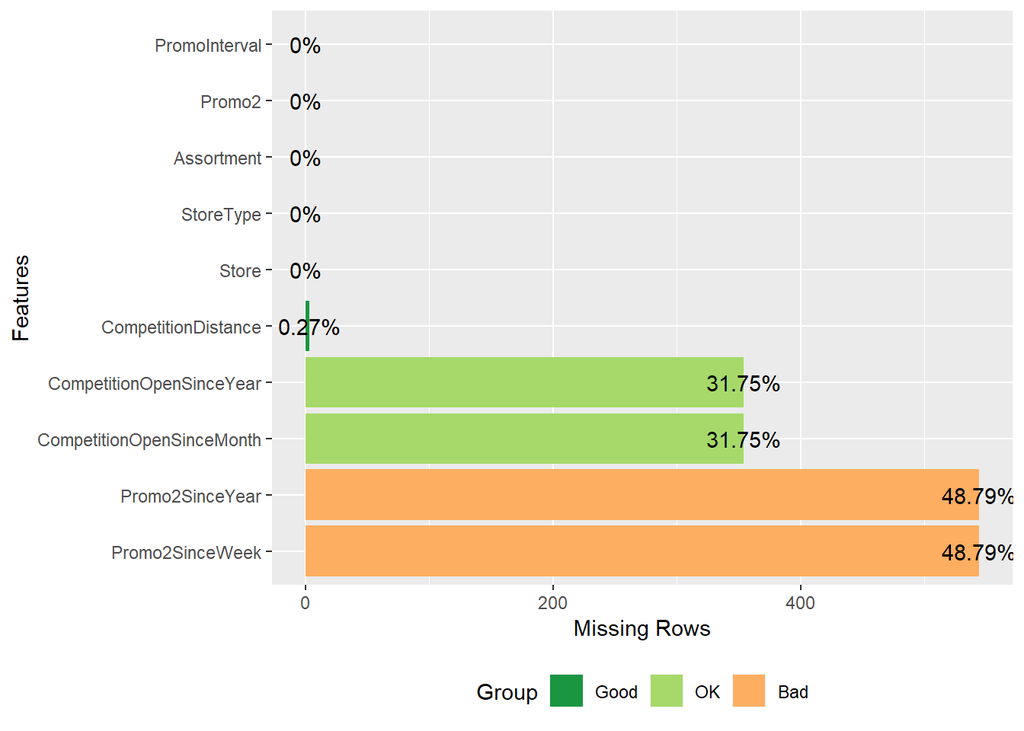

For given data, such us Year, Week, Month, wich are non-numeric variables, imputing missing values with mode (the value which occurs most of the time) is a common choice.

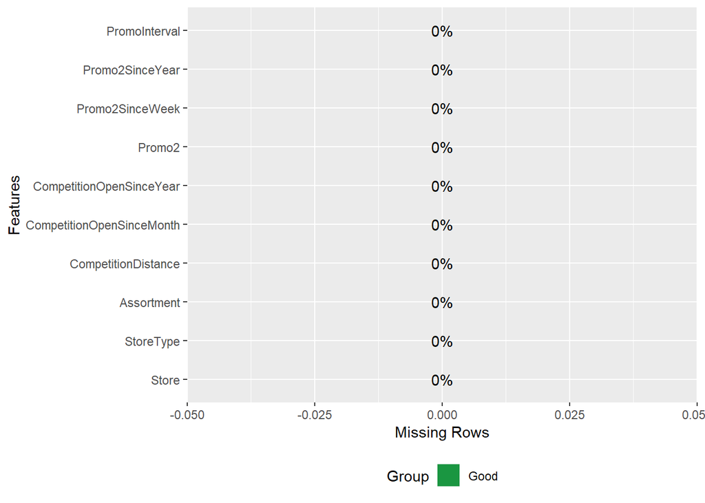

```r
# filling NAs for each variable with missings with the mode
# imputing the mode
store$CompetitionDistance[is.na(store$CompetitionDistance)] <- 250
store$CompetitionOpenSinceMonth[is.na(store$CompetitionOpenSinceMonth)] <- 8
store$CompetitionOpenSinceYear[is.na(store$CompetitionOpenSinceYear)] <- 2013
store$Promo2SinceYear[is.na(store$Promo2SinceYear)] <- 2012
store$Promo2SinceWeek[is.na(store$Promo2SinceWeek)] <- 22

plot_missing(store)
```

Then, after merging sales and store data, we extract the day, month, year and week (from the beggining of year) variables from the date. We also add new variable, which is the logarithm of sales and will be predicted.

```r
# combining the store and sales data into one set
sales <- merge(data, store, by = "Store")

# we seperate month and year variables from date
sales$Year <- as.numeric(strftime(sales$Date, format="%y"))
sales$Month <- as.numeric(strftime(sales$Date, format="%m"))
sales$Day <- as.numeric(strftime(sales$Date, format="%d"))
sales$Week <- as.numeric(strftime(sales$Date, format="%W"))

# we want to order sales by dates
sales <- sales[order(sales$Date),]
```

```
## [1] "English_United States.1252"
```

#### 2.2 Exploratory Data Analysis

From the density plot, we see that our data is slightly right skewed. The frequency of sales seems to be higher when its values are low.

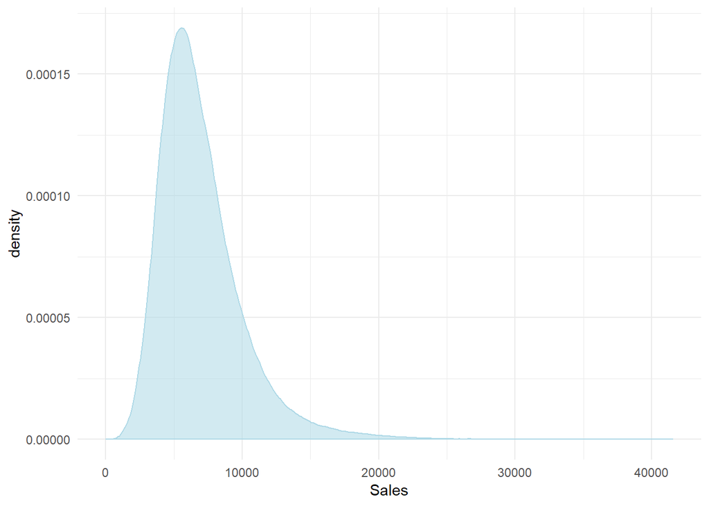

To account for the variability of sales data, we would like to implement the logarithm of sales variable in forecasting, which is considered a common approach when dealing with sales time series and is less sensitive to high sales.

After taking the logarithm, the distribution of sales is less skewed and we manage to flatten the data.

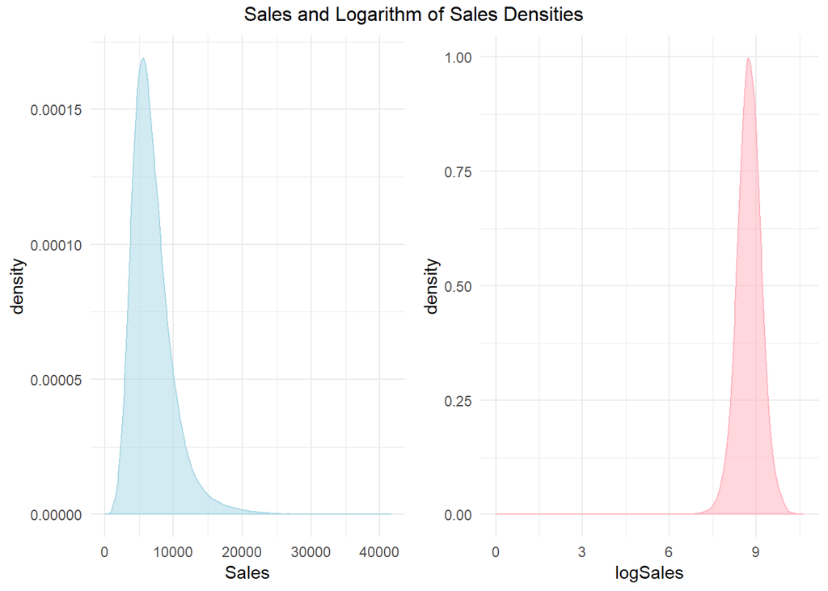

As one may expect, the correlation between sales and customers is high and positive. When we illustrate the scatterplot, we observe that the type of store seem to correpsond to the dispertion of the correlation, meaning each store type slightly differs in correlation with the number of customers. We may, therefore, suspect the store type to be a somewhat significant factor influencig the level of sales for a store, and thus worth keeping.

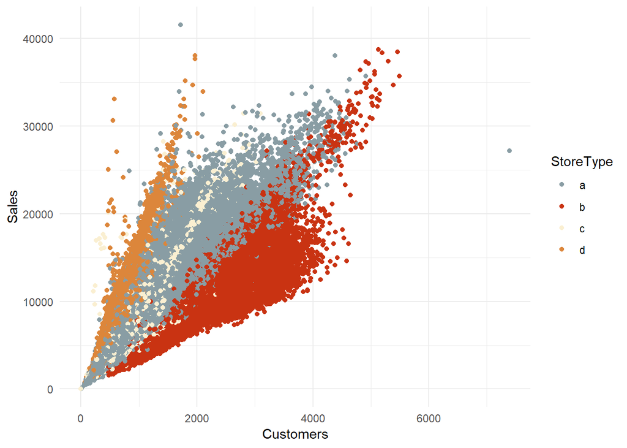

The Promo (short-term/daily promotion) and Promo2 (consecutive long-term promotion) seem to also infleunce the level of sales, however, in quite opposite manners.

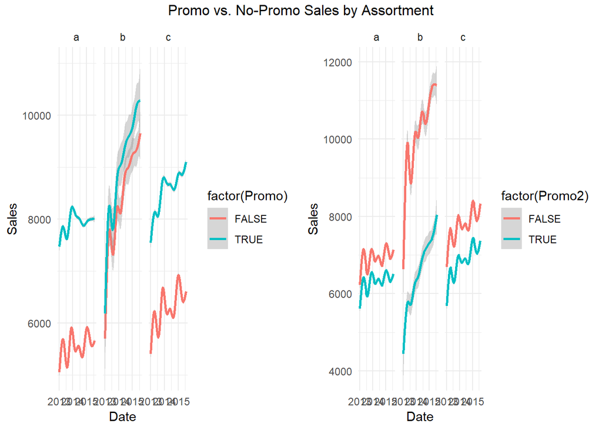

#### 2.3 Feature Engineering

We further inspect the significance of Promo factor using the Welch Two Sample t-test and find that promotions have a significant impact on sales, which are about 40 percent higher on average during promotions.

```r
t.test(sales[sales$Promo,]$Sales,sales[!sales$Promo,]$Sales)
```

```
##
##  Welch Two Sample t-test
##
## data:  sales[sales$Promo, ]$Sales and sales[!sales$Promo, ]$Sales
## t = 356.64, df = 729120, p-value < 2.2e-16
## alternative hypothesis: true difference in means is not equal to 0
## 95 percent confidence interval:
##  2286.240 2311.508
## sample estimates:
## mean of x mean of y
##  8228.281  5929.408
```

```r
t.test(sales[sales$Promo2,]$Sales,sales[!sales$Promo2,]$Sales)
```

```
##
##  Welch Two Sample t-test
##
## data:  sales[sales$Promo2, ]$Sales and sales[!sales$Promo2, ]$Sales
## t = -118.28, df = 808420, p-value < 2.2e-16
## alternative hypothesis: true difference in means is not equal to 0
## 95 percent confidence interval:
##  -805.2984 -779.0454
## sample estimates:
## mean of x mean of y
##  6558.386  7350.558
```

When taking into account the averages sales, the sales for certain stores that are open on Sundays are highest on Sundays. Although the day of week variable does not have much influence on sales, as the sales are rather equally distributed over the week, incorporating information of whether a store is closed or open on Sundays may have a significant impact on forecasting the store’s performance when it comes to sales. Therefore, instead of **DayOfWeek** and **Open** variables we rather introduce the **isSunday** variable, indicating whether sales are on Sunday or not. Stores in Germany are mostly closed on Sundays expect from few time a year. We may therefore suspect during these times very high sales levels, what explains the high sales average on Sundays.

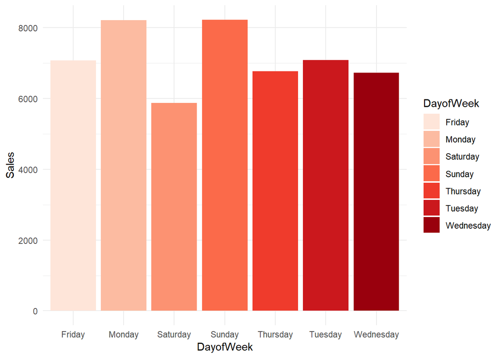

```
## $x
## [1] "Day of Week"
##
## $y
## [1] "Sales"
##
## $title
## [1] "Mean Sales by Day-of-Week"
##
## attr(,"class")
## [1] "labels"
```

Sales are highest on Mondays and Sundays and fairly equally distributed over the rest of days within the week. Their level, in constrast, is lowest on Saturdays, which can result from the fact that some stores close earlier on Saturday.

```r
# introducing the 'isSunday' variable using one_hot_encoder() function to create binary response

hot_encoder <- build_encoding(sales, cols = "DayOfWeek")
```

```
## [1] "build_encoding: I will compute encoding on 1 character and factor columns."
## [1] "build_encoding: it took me: 0.02s to compute encoding for 1 character and factor columns."
```

```r
sales <- one_hot_encoder(sales, encoding = hot_encoder)
```

```
## [1] "one_hot_encoder: I will one hot encode some columns."
## [1] "one_hot_encoder: I am doing column: DayOfWeek"
## [1] "one_hot_encoder: It took me 0.2s to transform 1 column(s)."
```

```r
# renaming the name of the column fo DayOfWeek.7 to isSunday
colnames(sales)[colnames(sales)=="DayOfWeek.7"] <- "isSunday"
sales[,30] <- sales[,30] == 1
```

Finally, we consider the state holidays as important factors, but the school holiday variable not worth including in modelling.

When looking closer on the two-months-period, we observe weekly patterns in sales trend.

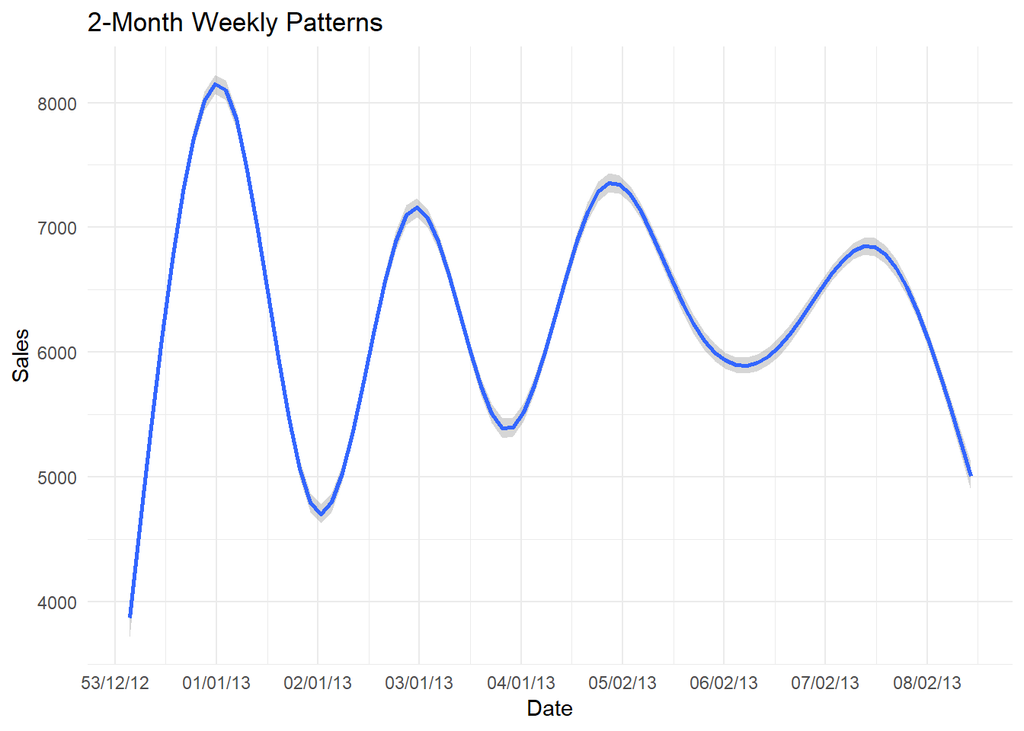

Intuitively, the best candidate for a predictor for future sales could be past sales. Because **Customers** variable is already a significant factor influencing sales, why not add information aboue avarage sales per customer on a particular day? This could be an indicator of the significance of introducting promotion campaigns and some regular customer offers that aim at cumulating the number of loyal customers and their baskets of transactions. We are going to use both the **Customers** and **SalesPerCustomer** variables in our model, because they influence the level of sales strongly. However, because of high correlation it may seem like making predictions of something which is already known, as the customers correspond to the value of sales. Therefore, to account for the look-ahead bias, we will use the **lagged customers** and **sales per customer** data, taking the observations for the same day, but week before.

```r
# Extracting one-week lagged observations for customers, adding lagged sales per customer
myDf <- as.data.frame(sales)
myDf <- slide(myDf, "Customers", GroupVar = "Store", NewVar = "CustomersLag7", slideBy = -7)
```

```
##
## Remember to order myDf by Store and the time variable before running.
```

```
##
## Lagging Customers by 7 time units.
```

```r
myDf$SalesPerCustomer <- myDf$Sales/myDf$Customers
myDf <- slide(myDf, "SalesPerCustomer", GroupVar = "Store", NewVar = "SalesPerCustomerLag7", slideBy = -7)
```

```
##
## Remember to order myDf by Store and the time variable before running.
```

```
##
## Lagging SalesPerCustomer by 7 time units.
```

```r
sales <- na.omit(myDf)
```

## 3. Regression

#### 3.1. Regression Tree

For our analysis, we only use the train.csv set provided by Kaggle. We treat it as our initial dataset, and divide it on our own into new train and test sets in proportions 70% vs. 30% respectively. We build a model formula with the following components:

```r
model.formula <- logSales ~ SalesPerCustomerLag7 + CustomersLag7 + Assortment + Promo + StoreType + CompetitionDistance + isSunday + Year + Month + Week + Day + StateHoliday + CompetitionOpenSinceMonth + CompetitionOpenSinceYear + Promo2SinceWeek + Promo2SinceYear
```

The above formula is further used in every machine learning method.

```r
# Creating data partition
set.seed(12345678)
index <- createDataPartition(sales$Sales, p = 0.7, list = FALSE)

train <- sales[index, ]

test <-  sales[-index, ]

# to fasten computations randomly choose 10000 observations
# from the original training data set
set.seed(12345678)
train2 <- train[sample(1:nrow(train),
                                size = 10000,
                                replace = FALSE),]
```

The we use the train set sample to train our initial regression tree model.

```r
regTree_model <- rpart(formula = model.formula,
                        data = train2,
                        method = "anova")
regTree_model
```

```
## n= 10000
##
## node), split, n, deviance, yval
##       * denotes terminal node
##
##  1) root 10000 1754.54600 8.753247
##    2) Promo< 0.5 5614  914.46250 8.603929
##      4) CustomersLag7< 882.5 3894  477.49440 8.475055
##        8) CustomersLag7< 583.5 1658  206.83780 8.348430
##         16) SalesPerCustomerLag7< 9.780237 631   79.90541 8.190060 *
##         17) SalesPerCustomerLag7>=9.780237 1027  101.38250 8.445734 *
##        9) CustomersLag7>=583.5 2236  224.36000 8.568948
##         18) SalesPerCustomerLag7< 10.40612 1338  123.45480 8.482393 *
##         19) SalesPerCustomerLag7>=10.40612 898   75.94591 8.697912 *
##      5) CustomersLag7>=882.5 1720  225.87490 8.895695
##       10) CustomersLag7< 1529 1454  141.16530 8.818405 *
##       11) CustomersLag7>=1529 266   28.54533 9.318177 *
##    3) Promo>=0.5 4386  554.70020 8.944372
##      6) CustomersLag7< 719.5 2760  267.15390 8.812480
##       12) SalesPerCustomerLag7< 8.593083 944   80.54705 8.671530 *
##       13) SalesPerCustomerLag7>=8.593083 1816  158.10350 8.885750
##         26) CustomersLag7< 446.5 645   51.45726 8.720165 *
##         27) CustomersLag7>=446.5 1171   79.22054 8.976955 *
##      7) CustomersLag7>=719.5 1626  158.04000 9.168247
##       14) CustomersLag7< 1295.5 1368   97.43422 9.106104 *
##       15) CustomersLag7>=1295.5 258   27.31160 9.497748 *
```

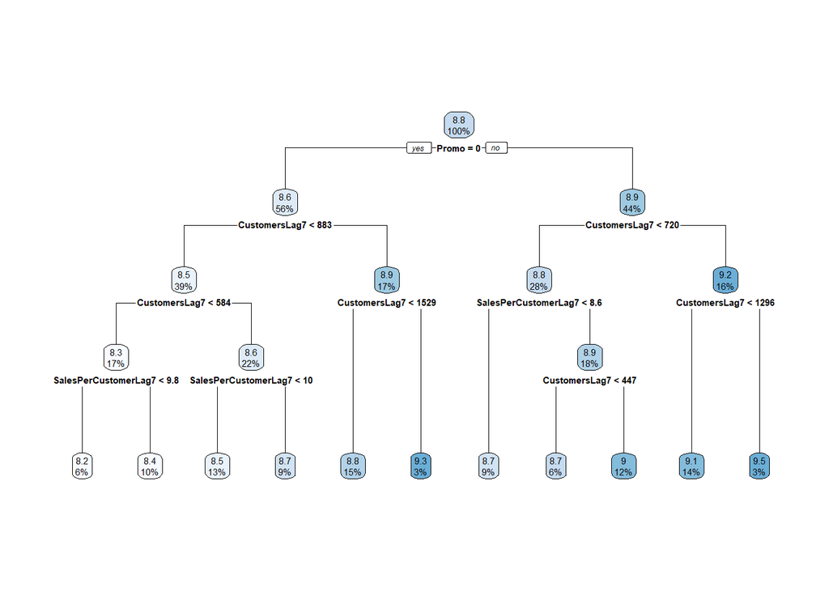

```r
rpart.plot(regTree_model)
```

Given the metrics, we see relatively low RMSE for log of sales, similar in both train and test sets, and therefore no instance of overfitting.

Train:

| MSE | RMSE | MAE | R2 |
| --- | --- | --- | --- |
| 0.0932953 | 0.3054428 | 0.2365264 | 0.4828549 |
| Test: |  |  |  |

| MSE | RMSE | MAE | R2 |
| --- | --- | --- | --- |
| 0.0950215 | 0.3082556 | 0.2379263 | 0.4776838 |

We further try to improve the model by hyper-parameters tuning by means of grid-search and 3-folds cross-validation.

```r
# Tuning and cross-validation

# Cross-validation
cv_ctrl3 <- trainControl(method = "cv",
                         number = 3)
cv.grid <- expand.grid(cp = seq(0, 0.03, 0.001))

set.seed(12345678)
regTree_tuned <- train(model.formula,
                  data = train2,
                  method = "rpart",
                  trControl = cv_ctrl3,
                  tuneGrid = cv.grid)
```

Train:

| MSE | RMSE | MAE | R2 |
| --- | --- | --- | --- |
| 0.0822991 | 0.2868781 | 0.2201208 | 0.5438083 |
| Test: |  |  |  |

| MSE | RMSE | MAE | R2 |
| --- | --- | --- | --- |
| 0.0839876 | 0.2898061 | 0.2215274 | 0.5383356 |

#### 3.2. Random Forest

When training a random forest, we start with mtry equal to 5, which is close to the square root of number of the predictors used. Again, we use the sample of 10,000 observations in training the model.

```r
## Random forest

rf_model <- randomForest(model.formula,
                         data = train2,
                         mtry = 5,
                         ntree = 50,
                         do.trace = TRUE,
                         importance = TRUE)
```

```
##      |      Out-of-bag   |
## Tree |      MSE  %Var(y) |
##    1 |   0.1389    79.18 |
##    2 |   0.1277    72.77 |
##    3 |    0.117    66.67 |
##    4 |   0.1069    60.95 |
##    5 |   0.1012    57.69 |
##    6 |  0.09542    54.38 |
##    7 |  0.09012    51.36 |
##    8 |  0.08668    49.40 |
##    9 |  0.08296    47.28 |
##   10 |  0.07957    45.35 |
##   11 |  0.07676    43.75 |
##   12 |  0.07482    42.65 |
##   13 |  0.07342    41.85 |
```

[output cut: 37 more lines]

```r
print(rf_model)
```

```
##
## Call:
##  randomForest(formula = model.formula, data = train2, mtry = 5,      ntree = 50, do.trace = TRUE, importance = TRUE)
##                Type of random forest: regression
##                      Number of trees: 50
## No. of variables tried at each split: 5
##
##           Mean of squared residuals: 0.05982711
##                     % Var explained: 65.9
```

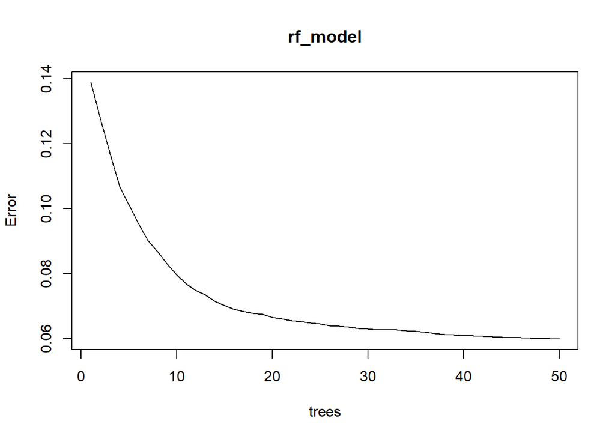

```r
# let us see it again on the plot with respect to number of trees
plot(rf_model)
```

```r
# inspecting the importance of predictors
importance(rf_model, type = 2)
```

```
##                           IncNodePurity
## SalesPerCustomerLag7         170.923455
## CustomersLag7                577.624412
## Assortment                    30.392299
## Promo                        299.506632
## StoreType                     45.306204
## CompetitionDistance          119.922435
## isSunday                       4.822638
## Year                          21.766529
## Month                         45.393641
## Week                          79.197441
## Day                          100.604895
## StateHoliday                   1.324263
## CompetitionOpenSinceMonth     51.313011
## CompetitionOpenSinceYear      56.702171
## Promo2SinceWeek               45.264926
## Promo2SinceYear               35.654869
```

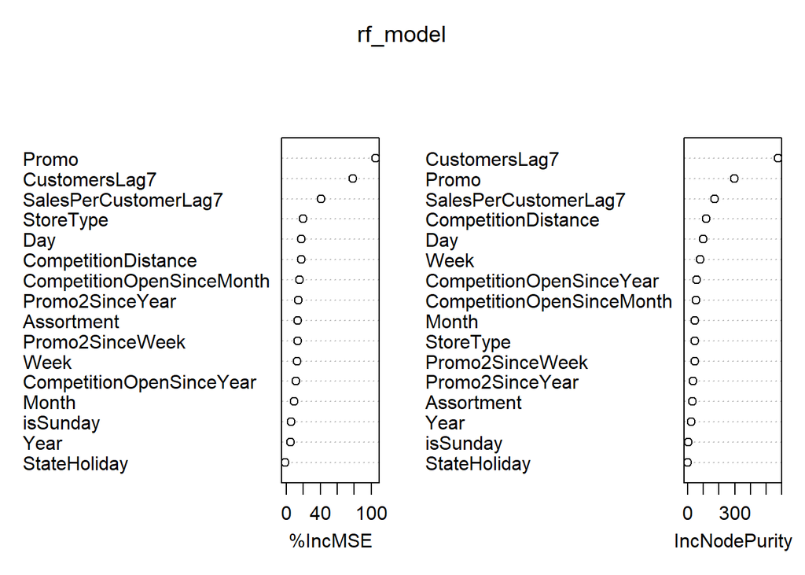

```r
varImpPlot(rf_model)
```

```
## -0.01830844 0.01
## -0.02204475 0.01
```

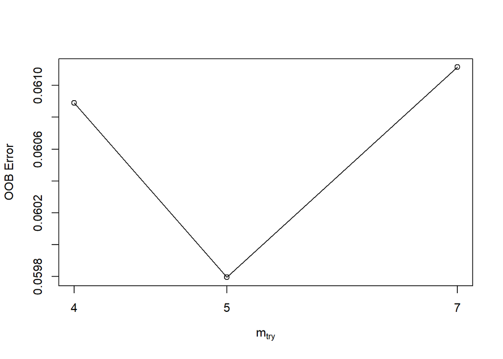

```
## 5
## 5
```

```
##      |      Out-of-bag   |
## Tree |      MSE  %Var(y) |
##    1 |    0.112    62.10 |
##    2 |  0.08287    45.93 |
##    3 |  0.07131    39.53 |
##    4 |  0.06697    37.12 |
##    5 |  0.06394    35.44 |
##    6 |  0.06185    34.28 |
##    7 |  0.06064    33.61 |
##    8 |  0.05935    32.90 |
##    9 |   0.0585    32.43 |
##   10 |  0.05786    32.07 |
##   11 |  0.05735    31.79 |
##   12 |  0.05658    31.36 |
##   13 |  0.05628    31.20 |
```

[output cut: 187 more lines]

```
##
## Call:
##  randomForest(formula = model.formula, data = train, mtry = 5,      ntree = 200, sampsize = 10000, do.trace = TRUE, importance = TRUE)
##                Type of random forest: regression
##                      Number of trees: 200
## No. of variables tried at each split: 5
##
##           Mean of squared residuals: 0.05161767
##                     % Var explained: 71.39
```

The optimal **mtry** at which the OOB error is minimalized is found to be equal to 5. We print the evaluation results.

| MSE | RMSE | MAE | R2 |
| --- | --- | --- | --- |
| 0.0502711 | 0.2242121 | 0.1693219 | 0.7213425 |

| MSE | RMSE | MAE | R2 |
| --- | --- | --- | --- |
| 0.0528859 | 0.2299693 | 0.1726794 | 0.7092959 |

The Random Forest method provides better regression results, however, it has some tendency to overfit.

#### 3.3. Gradient Boosting

Finally, we try our last model, which is gradient boosting using the Gradient Boosting Machine method.

```
## assuming text variables are categorical & replacing them with numeric ids
```

```
## gbm(formula = model.formula, distribution = "gaussian", data = train2,
##     n.trees = 500, interaction.depth = 4, shrinkage = 0.01, verbose = FALSE)
## A gradient boosted model with gaussian loss function.
## 500 iterations were performed.
## There were 16 predictors of which 12 had non-zero influence.
```

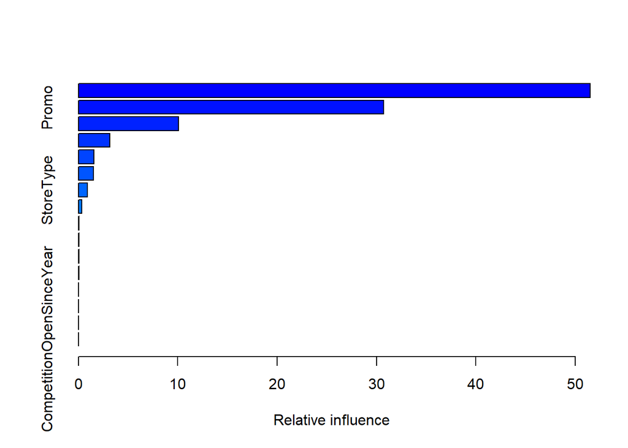

```
##                                                 var     rel.inf
## CustomersLag7                         CustomersLag7 51.50990845
## Promo                                         Promo 30.74242334
## SalesPerCustomerLag7           SalesPerCustomerLag7 10.09455702
## Day                                             Day  3.17966641
## Week                                           Week  1.54200445
## Assortment                               Assortment  1.49078609
## StoreType                                 StoreType  0.90474650
## CompetitionDistance             CompetitionDistance  0.32971672
## Promo2SinceWeek                     Promo2SinceWeek  0.07158010
## isSunday                                   isSunday  0.06161353
## Month                                         Month  0.03974916
## Promo2SinceYear                     Promo2SinceYear  0.03324822
## Year                                           Year  0.00000000
## StateHoliday                           StateHoliday  0.00000000
## CompetitionOpenSinceMonth CompetitionOpenSinceMonth  0.00000000
## CompetitionOpenSinceYear   CompetitionOpenSinceYear  0.00000000
```

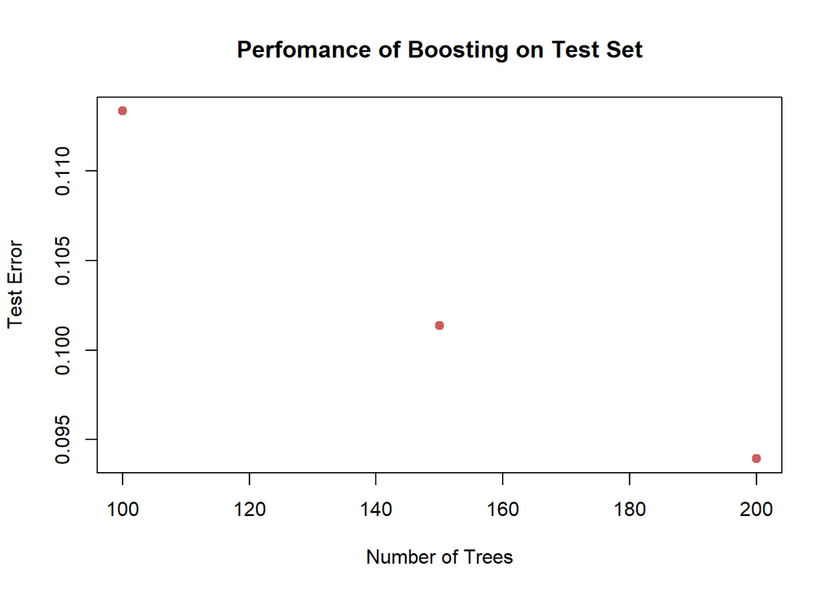

| MSE | RMSE | MAE | R2 |
| --- | --- | --- | --- |
| 0.0884528 | 0.2974101 | 0.2275493 | 0.4958653 |

| MSE | RMSE | MAE | R2 |
| --- | --- | --- | --- |
| 0.0939388 | 0.3064944 | 0.2341234 | 0.4836354 |

The given results are not better than in the case of regular Random Forest with optimal mtry. However, it has been shown that GBM should perform better than RF when parameters tuned carefully.

```r
# GBM tuning
parameters_gbm <- expand.grid(interaction.depth = c(3, 5),
                              n.trees = c(100, 200),
                              shrinkage = c(0.01, 0.1),
                              n.minobsinnode = c(5, 10, 15, 50))
ctrl_cv3 <- trainControl(method = "cv",
                         number = 3)
```

Results after tuning:

| MSE | RMSE | MAE | R2 |
| --- | --- | --- | --- |
| 0.054258 | 0.2329336 | 0.1790743 | 0.6907574 |

| MSE | RMSE | MAE | R2 |
| --- | --- | --- | --- |
| 0.0633022 | 0.2515992 | 0.1907693 | 0.6520395 |

The results are already much better.

## 4. Final models evaluation & conclusions

Given all the best models for each machine learning method, we receive the following results for the test set:

**Regression Tree**

| MSE | RMSE | MAE | R2 |
| --- | --- | --- | --- |
| 0.0839876 | 0.2898061 | 0.2215274 | 0.5383356 |

**Random Forest**

| MSE | RMSE | MAE | R2 |
| --- | --- | --- | --- |
| 0.0528859 | 0.2299693 | 0.1726794 | 0.7092959 |

**Gradient Boosting Machine**

| MSE | RMSE | MAE | R2 |
| --- | --- | --- | --- |
| 0.0633022 | 0.2515992 | 0.1907693 | 0.6520395 |

The best performing algorithm seems to be the Random Forest after tuning, with the lowest RMSE and highest R^2, however, it suffers from some overfitting. The closest in terms of train and test predictions is the Regression Tree model with no instance of overfit.

## References

Rossmann Store Sales: Kaggle competition: https://www.kaggle.com/c/rossmann-store-sales